# Risk Factor Analysis

## Outcome Variable

**Outcome Variable:** wasted

## Predictor Variables

**Intervention Variable:** parity

**Adjustment Set:**

- arm
- W_mage
- meducyrs
- feducyrs
- hhwealth_quart
- hfoodsec
- W_mhtcm
- vagbrth
- W_nrooms
- impfloor
- impsan
- safeh20
- delta_W_mage
- delta_meducyrs
- delta_feducyrs
- delta_hhwealth_quart
- delta_hfoodsec
- delta_W_mhtcm
- delta_vagbrth
- delta_W_nrooms
- delta_impfloor
- delta_impsan
- delta_safeh20

## Stratifying Variables

The analysis was stratified on these variable(s):

- agecat
- studyid
- country

## Data Summary

| agecat | studyid | country | parity | wasted | n_cell | n |
| --- | --- | --- | --- | --- | --- | --- |
| Birth | ki1000304b-SAS-CompFeed | INDIA | 1 | 0 | 37 | 166 |
| Birth | ki1000304b-SAS-CompFeed | INDIA | 1 | 1 | 4 | 166 |
| Birth | ki1000304b-SAS-CompFeed | INDIA | 2 | 0 | 41 | 166 |
| Birth | ki1000304b-SAS-CompFeed | INDIA | 2 | 1 | 3 | 166 |
| Birth | ki1000304b-SAS-CompFeed | INDIA | 3+ | 0 | 77 | 166 |
| Birth | ki1000304b-SAS-CompFeed | INDIA | 3+ | 1 | 4 | 166 |
| Birth | ki1101329-Keneba | GAMBIA | 1 | 0 | 139 | 1292 |
| Birth | ki1101329-Keneba | GAMBIA | 1 | 1 | 3 | 1292 |
| Birth | ki1101329-Keneba | GAMBIA | 2 | 0 | 131 | 1292 |
| Birth | ki1101329-Keneba | GAMBIA | 2 | 1 | 2 | 1292 |
| Birth | ki1101329-Keneba | GAMBIA | 3+ | 0 | 996 | 1292 |
| Birth | ki1101329-Keneba | GAMBIA | 3+ | 1 | 21 | 1292 |
| Birth | ki1126311-ZVITAMBO | ZIMBABWE | 1 | 0 | 4497 | 12915 |
| Birth | ki1126311-ZVITAMBO | ZIMBABWE | 1 | 1 | 1064 | 12915 |
| Birth | ki1126311-ZVITAMBO | ZIMBABWE | 2 | 0 | 3358 | 12915 |
| Birth | ki1126311-ZVITAMBO | ZIMBABWE | 2 | 1 | 524 | 12915 |
| Birth | ki1126311-ZVITAMBO | ZIMBABWE | 3+ | 0 | 3000 | 12915 |
| Birth | ki1126311-ZVITAMBO | ZIMBABWE | 3+ | 1 | 472 | 12915 |
| Birth | ki1135781-COHORTS | GUATEMALA | 1 | 0 | 66 | 756 |
| Birth | ki1135781-COHORTS | GUATEMALA | 1 | 1 | 28 | 756 |
| Birth | ki1135781-COHORTS | GUATEMALA | 2 | 0 | 87 | 756 |
| Birth | ki1135781-COHORTS | GUATEMALA | 2 | 1 | 31 | 756 |
| Birth | ki1135781-COHORTS | GUATEMALA | 3+ | 0 | 411 | 756 |
| Birth | ki1135781-COHORTS | GUATEMALA | 3+ | 1 | 133 | 756 |
| Birth | ki1135781-COHORTS | INDIA | 1 | 0 | 505 | 3855 |
| Birth | ki1135781-COHORTS | INDIA | 1 | 1 | 136 | 3855 |
| Birth | ki1135781-COHORTS | INDIA | 2 | 0 | 823 | 3855 |
| Birth | ki1135781-COHORTS | INDIA | 2 | 1 | 159 | 3855 |
| Birth | ki1135781-COHORTS | INDIA | 3+ | 0 | 1876 | 3855 |
| Birth | ki1135781-COHORTS | INDIA | 3+ | 1 | 356 | 3855 |

[output cut: 132 more lines]

The following strata were considered:

- agecat: 24 months, studyid: ki1017093b-PROVIDE, country: BANGLADESH
- agecat: 24 months, studyid: ki1066203-TanzaniaChild2, country: TANZANIA, UNITED REPUBLIC OF
- agecat: 24 months, studyid: ki1101329-Keneba, country: GAMBIA
- agecat: 24 months, studyid: ki1113344-GMS-Nepal, country: NEPAL
- agecat: 24 months, studyid: ki1126311-ZVITAMBO, country: ZIMBABWE
- agecat: 24 months, studyid: ki1135781-COHORTS, country: GUATEMALA
- agecat: 24 months, studyid: ki1135781-COHORTS, country: INDIA
- agecat: 24 months, studyid: ki1135781-COHORTS, country: PHILIPPINES
- agecat: 24 months, studyid: kiGH5241-JiVitA-3, country: BANGLADESH
- agecat: 6 months, studyid: ki1000304b-SAS-CompFeed, country: INDIA
- agecat: 6 months, studyid: ki1000304b-SAS-FoodSuppl, country: INDIA
- agecat: 6 months, studyid: ki1017093b-PROVIDE, country: BANGLADESH
- agecat: 6 months, studyid: ki1066203-TanzaniaChild2, country: TANZANIA, UNITED REPUBLIC OF
- agecat: 6 months, studyid: ki1101329-Keneba, country: GAMBIA
- agecat: 6 months, studyid: ki1113344-GMS-Nepal, country: NEPAL
- agecat: 6 months, studyid: ki1126311-ZVITAMBO, country: ZIMBABWE
- agecat: 6 months, studyid: ki1135781-COHORTS, country: GUATEMALA
- agecat: 6 months, studyid: ki1135781-COHORTS, country: INDIA
- agecat: 6 months, studyid: ki1135781-COHORTS, country: PHILIPPINES
- agecat: 6 months, studyid: kiGH5241-JiVitA-3, country: BANGLADESH
- agecat: Birth, studyid: ki1000304b-SAS-CompFeed, country: INDIA
- agecat: Birth, studyid: ki1101329-Keneba, country: GAMBIA
- agecat: Birth, studyid: ki1126311-ZVITAMBO, country: ZIMBABWE
- agecat: Birth, studyid: ki1135781-COHORTS, country: GUATEMALA
- agecat: Birth, studyid: ki1135781-COHORTS, country: INDIA
- agecat: Birth, studyid: ki1135781-COHORTS, country: PHILIPPINES
- agecat: Birth, studyid: kiGH5241-JiVitA-3, country: BANGLADESH

### Dropped Strata

Some strata were dropped due to rare outcomes:

- agecat: Birth, studyid: ki1000304b-SAS-CompFeed, country: INDIA
- agecat: Birth, studyid: ki1101329-Keneba, country: GAMBIA
- agecat: 6 months, studyid: ki1135781-COHORTS, country: GUATEMALA
- agecat: 24 months, studyid: ki1066203-TanzaniaChild2, country: TANZANIA, UNITED REPUBLIC OF

## Methods Detail

We’re interested in the causal parameters $E[Y_a]$ for all values of $a \in \mathcal{A}$. These parameters represent the mean outcome if, possibly contrary to fact, we intervened to set all units to have $A=a$. Under the randomization and positivity assumptions, these are identified by the statistical parameters $\psi_a=E_W[E_{Y|A,W}(Y|A=a,W)]$. In addition, we’re interested in the mean of $Y$, $E[Y]$ under no intervention (the observed mean). We will estimate these parameters by using SuperLearner to fit the relevant likelihood factors – $E_{Y|A,W}(Y|A=a,W)$ and $p(A=a|W)$, and then updating our likelihood fit using a joint TMLE.

For unadjusted analyses ($W=\{\}$), initial likelihoods were estimated using Lrnr_glm to estimate the simple $E(Y|A)$ and Lrnr_mean to estimate $p(A)$. For adjusted analyses, a small library containing Lrnr_glmnet, Lrnr_xgboost, and Lrnr_mean was used.

Having estimated these parameters, we will then use the delta method to estimate relative risks and attributable risks relative to a prespecified baseline level of $A$.

# Results Detail

## Results Plots

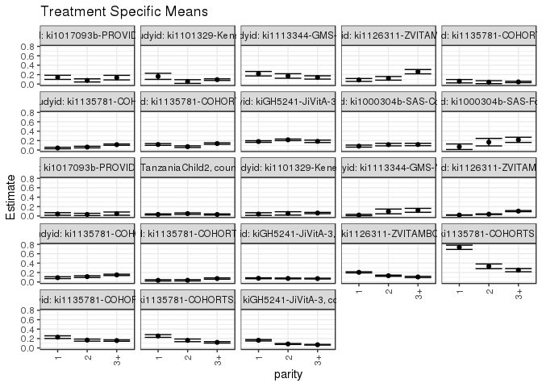

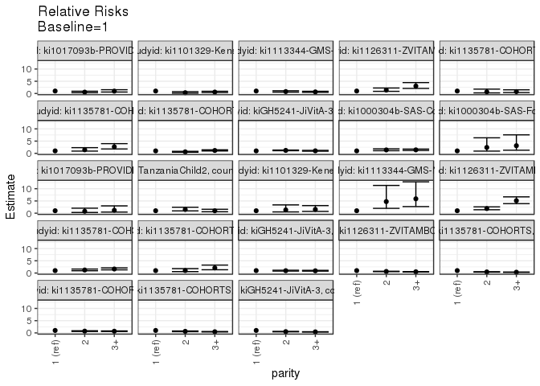

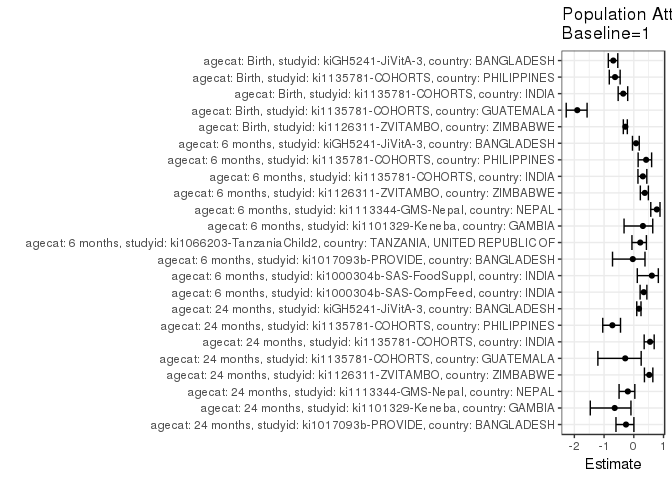

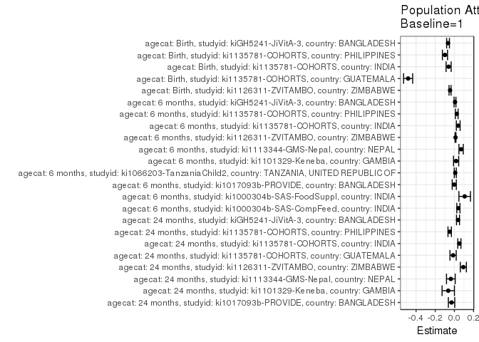

## Results Table

### Parameter: TSM

| agecat | studyid | country | intervention_level | baseline_level | estimate | ci_lower | ci_upper |
| --- | --- | --- | --- | --- | --- | --- | --- |
| Birth | ki1126311-ZVITAMBO | ZIMBABWE | 1 | NA | 0.2047046 | 0.1923962 | 0.2170130 |
| Birth | ki1126311-ZVITAMBO | ZIMBABWE | 2 | NA | 0.1326318 | 0.1204605 | 0.1448030 |
| Birth | ki1126311-ZVITAMBO | ZIMBABWE | 3+ | NA | 0.1062889 | 0.0919765 | 0.1206013 |
| Birth | ki1135781-COHORTS | GUATEMALA | 1 | NA | 0.7368540 | 0.6916013 | 0.7821068 |
| Birth | ki1135781-COHORTS | GUATEMALA | 2 | NA | 0.3321005 | 0.2820206 | 0.3821804 |
| Birth | ki1135781-COHORTS | GUATEMALA | 3+ | NA | 0.2510024 | 0.2177893 | 0.2842156 |
| Birth | ki1135781-COHORTS | INDIA | 1 | NA | 0.2290218 | 0.2006378 | 0.2574057 |
| Birth | ki1135781-COHORTS | INDIA | 2 | NA | 0.1659592 | 0.1434861 | 0.1884323 |
| Birth | ki1135781-COHORTS | INDIA | 3+ | NA | 0.1573050 | 0.1420834 | 0.1725266 |
| Birth | ki1135781-COHORTS | PHILIPPINES | 1 | NA | 0.2538663 | 0.2244978 | 0.2832348 |
| Birth | ki1135781-COHORTS | PHILIPPINES | 2 | NA | 0.1613946 | 0.1334710 | 0.1893182 |
| Birth | ki1135781-COHORTS | PHILIPPINES | 3+ | NA | 0.1190418 | 0.1032418 | 0.1348418 |
| Birth | kiGH5241-JiVitA-3 | BANGLADESH | 1 | NA | 0.1622538 | 0.1470906 | 0.1774170 |
| Birth | kiGH5241-JiVitA-3 | BANGLADESH | 2 | NA | 0.0841951 | 0.0743514 | 0.0940388 |
| Birth | kiGH5241-JiVitA-3 | BANGLADESH | 3+ | NA | 0.0678445 | 0.0602000 | 0.0754891 |
| 6 months | ki1000304b-SAS-CompFeed | INDIA | 1 | NA | 0.0826707 | 0.0609750 | 0.1043665 |
| 6 months | ki1000304b-SAS-CompFeed | INDIA | 2 | NA | 0.1153086 | 0.0887313 | 0.1418859 |
| 6 months | ki1000304b-SAS-CompFeed | INDIA | 3+ | NA | 0.1170630 | 0.0915684 | 0.1425575 |
| 6 months | ki1000304b-SAS-FoodSuppl | INDIA | 1 | NA | 0.0694444 | 0.0106475 | 0.1282414 |
| 6 months | ki1000304b-SAS-FoodSuppl | INDIA | 2 | NA | 0.1666667 | 0.0868626 | 0.2464708 |
| 6 months | ki1000304b-SAS-FoodSuppl | INDIA | 3+ | NA | 0.2165899 | 0.1617098 | 0.2714700 |
| 6 months | ki1017093b-PROVIDE | BANGLADESH | 1 | NA | 0.0426540 | 0.0153646 | 0.0699435 |
| 6 months | ki1017093b-PROVIDE | BANGLADESH | 2 | NA | 0.0330189 | 0.0089451 | 0.0570926 |
| 6 months | ki1017093b-PROVIDE | BANGLADESH | 3+ | NA | 0.0503145 | 0.0163082 | 0.0843208 |
| 6 months | ki1066203-TanzaniaChild2 | TANZANIA, UNITED REPUBLIC OF | 1 | NA | 0.0333352 | 0.0214059 | 0.0452645 |
| 6 months | ki1066203-TanzaniaChild2 | TANZANIA, UNITED REPUBLIC OF | 2 | NA | 0.0504220 | 0.0344660 | 0.0663781 |
| 6 months | ki1066203-TanzaniaChild2 | TANZANIA, UNITED REPUBLIC OF | 3+ | NA | 0.0322578 | 0.0208092 | 0.0437064 |
| 6 months | ki1101329-Keneba | GAMBIA | 1 | NA | 0.0410256 | 0.0131775 | 0.0688738 |
| 6 months | ki1101329-Keneba | GAMBIA | 2 | NA | 0.0548780 | 0.0200120 | 0.0897441 |
| 6 months | ki1101329-Keneba | GAMBIA | 3+ | NA | 0.0625000 | 0.0491515 | 0.0758485 |
| 6 months | ki1113344-GMS-Nepal | NEPAL | 1 | NA | 0.0203998 | 0.0061137 | 0.0346858 |
| 6 months | ki1113344-GMS-Nepal | NEPAL | 2 | NA | 0.0965791 | 0.0460591 | 0.1470991 |
| 6 months | ki1113344-GMS-Nepal | NEPAL | 3+ | NA | 0.1199655 | 0.0781941 | 0.1617369 |
| 6 months | ki1126311-ZVITAMBO | ZIMBABWE | 1 | NA | 0.0202177 | 0.0153355 | 0.0250999 |
| 6 months | ki1126311-ZVITAMBO | ZIMBABWE | 2 | NA | 0.0385189 | 0.0311117 | 0.0459261 |
| 6 months | ki1126311-ZVITAMBO | ZIMBABWE | 3+ | NA | 0.1031927 | 0.0910970 | 0.1152885 |
| 6 months | ki1135781-COHORTS | INDIA | 1 | NA | 0.0911785 | 0.0709183 | 0.1114388 |
| 6 months | ki1135781-COHORTS | INDIA | 2 | NA | 0.1130398 | 0.0946548 | 0.1314247 |
| 6 months | ki1135781-COHORTS | INDIA | 3+ | NA | 0.1504801 | 0.1361588 | 0.1648015 |
| 6 months | ki1135781-COHORTS | PHILIPPINES | 1 | NA | 0.0347856 | 0.0208086 | 0.0487625 |
| 6 months | ki1135781-COHORTS | PHILIPPINES | 2 | NA | 0.0359186 | 0.0222352 | 0.0496020 |
| 6 months | ki1135781-COHORTS | PHILIPPINES | 3+ | NA | 0.0727107 | 0.0593364 | 0.0860849 |
| 6 months | kiGH5241-JiVitA-3 | BANGLADESH | 1 | NA | 0.0782048 | 0.0677436 | 0.0886659 |
| 6 months | kiGH5241-JiVitA-3 | BANGLADESH | 2 | NA | 0.0749929 | 0.0661608 | 0.0838250 |
| 6 months | kiGH5241-JiVitA-3 | BANGLADESH | 3+ | NA | 0.0719422 | 0.0637926 | 0.0800918 |
| 24 months | ki1017093b-PROVIDE | BANGLADESH | 1 | NA | 0.1420026 | 0.0982825 | 0.1857227 |
| 24 months | ki1017093b-PROVIDE | BANGLADESH | 2 | NA | 0.0770672 | 0.0438219 | 0.1103125 |
| 24 months | ki1017093b-PROVIDE | BANGLADESH | 3+ | NA | 0.1361672 | 0.0875745 | 0.1847599 |
| 24 months | ki1101329-Keneba | GAMBIA | 1 | NA | 0.1635916 | 0.0986391 | 0.2285440 |
| 24 months | ki1101329-Keneba | GAMBIA | 2 | NA | 0.0529582 | 0.0135965 | 0.0923199 |
| 24 months | ki1101329-Keneba | GAMBIA | 3+ | NA | 0.0935151 | 0.0761486 | 0.1108816 |
| 24 months | ki1113344-GMS-Nepal | NEPAL | 1 | NA | 0.2195781 | 0.1721517 | 0.2670044 |
| 24 months | ki1113344-GMS-Nepal | NEPAL | 2 | NA | 0.1711450 | 0.1231426 | 0.2191474 |
| 24 months | ki1113344-GMS-Nepal | NEPAL | 3+ | NA | 0.1400870 | 0.1049040 | 0.1752699 |
| 24 months | ki1126311-ZVITAMBO | ZIMBABWE | 1 | NA | 0.0865093 | 0.0558024 | 0.1172163 |
| 24 months | ki1126311-ZVITAMBO | ZIMBABWE | 2 | NA | 0.1210516 | 0.0821873 | 0.1599160 |
| 24 months | ki1126311-ZVITAMBO | ZIMBABWE | 3+ | NA | 0.2623502 | 0.2168566 | 0.3078437 |
| 24 months | ki1135781-COHORTS | GUATEMALA | 1 | NA | 0.0598802 | 0.0238784 | 0.0958821 |
| 24 months | ki1135781-COHORTS | GUATEMALA | 2 | NA | 0.0397351 | 0.0085646 | 0.0709056 |
| 24 months | ki1135781-COHORTS | GUATEMALA | 3+ | NA | 0.0448549 | 0.0301129 | 0.0595968 |
| 24 months | ki1135781-COHORTS | INDIA | 1 | NA | 0.0427627 | 0.0266535 | 0.0588720 |
| 24 months | ki1135781-COHORTS | INDIA | 2 | NA | 0.0620584 | 0.0452929 | 0.0788238 |
| 24 months | ki1135781-COHORTS | INDIA | 3+ | NA | 0.1136412 | 0.0996169 | 0.1276655 |
| 24 months | ki1135781-COHORTS | PHILIPPINES | 1 | NA | 0.1172900 | 0.0984983 | 0.1360818 |
| 24 months | ki1135781-COHORTS | PHILIPPINES | 2 | NA | 0.0709295 | 0.0531711 | 0.0886879 |
| 24 months | ki1135781-COHORTS | PHILIPPINES | 3+ | NA | 0.1368480 | 0.1200367 | 0.1536593 |
| 24 months | kiGH5241-JiVitA-3 | BANGLADESH | 1 | NA | 0.1803026 | 0.1633325 | 0.1972727 |
| 24 months | kiGH5241-JiVitA-3 | BANGLADESH | 2 | NA | 0.2164834 | 0.1996732 | 0.2332935 |
| 24 months | kiGH5241-JiVitA-3 | BANGLADESH | 3+ | NA | 0.1844705 | 0.1589679 | 0.2099732 |

### Parameter: E(Y)

| agecat | studyid | country | intervention_level | baseline_level | estimate | ci_lower | ci_upper |
| --- | --- | --- | --- | --- | --- | --- | --- |
| Birth | ki1126311-ZVITAMBO | ZIMBABWE | NA | NA | 0.1595045 | 0.1531895 | 0.1658194 |
| Birth | ki1135781-COHORTS | GUATEMALA | NA | NA | 0.2539683 | 0.2229196 | 0.2850169 |
| Birth | ki1135781-COHORTS | INDIA | NA | NA | 0.1688716 | 0.1570438 | 0.1806994 |
| Birth | ki1135781-COHORTS | PHILIPPINES | NA | NA | 0.1555709 | 0.1423748 | 0.1687670 |
| Birth | kiGH5241-JiVitA-3 | BANGLADESH | NA | NA | 0.0959725 | 0.0907703 | 0.1011747 |
| 6 months | ki1000304b-SAS-CompFeed | INDIA | NA | NA | 0.1244378 | 0.0992652 | 0.1496104 |
| 6 months | ki1000304b-SAS-FoodSuppl | INDIA | NA | NA | 0.1769437 | 0.1381636 | 0.2157238 |
| 6 months | ki1017093b-PROVIDE | BANGLADESH | NA | NA | 0.0412371 | 0.0250690 | 0.0574052 |
| 6 months | ki1066203-TanzaniaChild2 | TANZANIA, UNITED REPUBLIC OF | NA | NA | 0.0426279 | 0.0337587 | 0.0514970 |
| 6 months | ki1101329-Keneba | GAMBIA | NA | NA | 0.0591497 | 0.0476693 | 0.0706302 |
| 6 months | ki1113344-GMS-Nepal | NEPAL | NA | NA | 0.0905861 | 0.0668565 | 0.1143158 |
| 6 months | ki1126311-ZVITAMBO | ZIMBABWE | NA | NA | 0.0320707 | 0.0282716 | 0.0358698 |
| 6 months | ki1135781-COHORTS | INDIA | NA | NA | 0.1311552 | 0.1210467 | 0.1412637 |
| 6 months | ki1135781-COHORTS | PHILIPPINES | NA | NA | 0.0594974 | 0.0505830 | 0.0684118 |
| 6 months | kiGH5241-JiVitA-3 | BANGLADESH | NA | NA | 0.0846689 | 0.0798658 | 0.0894720 |
| 24 months | ki1017093b-PROVIDE | BANGLADESH | NA | NA | 0.1124567 | 0.0866788 | 0.1382347 |
| 24 months | ki1101329-Keneba | GAMBIA | NA | NA | 0.0995640 | 0.0837378 | 0.1153901 |
| 24 months | ki1113344-GMS-Nepal | NEPAL | NA | NA | 0.1827309 | 0.1487560 | 0.2167058 |
| 24 months | ki1126311-ZVITAMBO | ZIMBABWE | NA | NA | 0.1800948 | 0.1433886 | 0.2168010 |
| 24 months | ki1135781-COHORTS | GUATEMALA | NA | NA | 0.0464684 | 0.0338852 | 0.0590516 |
| 24 months | ki1135781-COHORTS | INDIA | NA | NA | 0.0945140 | 0.0846121 | 0.1044160 |
| 24 months | ki1135781-COHORTS | PHILIPPINES | NA | NA | 0.0681911 | 0.0582056 | 0.0781766 |
| 24 months | kiGH5241-JiVitA-3 | BANGLADESH | NA | NA | 0.2182836 | 0.2083649 | 0.2282022 |

### Parameter: RR

| agecat | studyid | country | intervention_level | baseline_level | estimate | ci_lower | ci_upper |
| --- | --- | --- | --- | --- | --- | --- | --- |
| Birth | ki1126311-ZVITAMBO | ZIMBABWE | 1 | 1 | 1.0000000 | 1.0000000 | 1.0000000 |
| Birth | ki1126311-ZVITAMBO | ZIMBABWE | 2 | 1 | 0.6479179 | 0.5806050 | 0.7230348 |
| Birth | ki1126311-ZVITAMBO | ZIMBABWE | 3+ | 1 | 0.5192307 | 0.4480957 | 0.6016584 |
| Birth | ki1135781-COHORTS | GUATEMALA | 1 | 1 | 1.0000000 | 1.0000000 | 1.0000000 |
| Birth | ki1135781-COHORTS | GUATEMALA | 2 | 1 | 0.4507006 | 0.3837976 | 0.5292660 |
| Birth | ki1135781-COHORTS | GUATEMALA | 3+ | 1 | 0.3406406 | 0.2946317 | 0.3938342 |
| Birth | ki1135781-COHORTS | INDIA | 1 | 1 | 1.0000000 | 1.0000000 | 1.0000000 |
| Birth | ki1135781-COHORTS | INDIA | 2 | 1 | 0.7246438 | 0.6034274 | 0.8702102 |
| Birth | ki1135781-COHORTS | INDIA | 3+ | 1 | 0.6868561 | 0.5872466 | 0.8033616 |
| Birth | ki1135781-COHORTS | PHILIPPINES | 1 | 1 | 1.0000000 | 1.0000000 | 1.0000000 |
| Birth | ki1135781-COHORTS | PHILIPPINES | 2 | 1 | 0.6357465 | 0.5163728 | 0.7827167 |
| Birth | ki1135781-COHORTS | PHILIPPINES | 3+ | 1 | 0.4689154 | 0.3932366 | 0.5591586 |
| Birth | kiGH5241-JiVitA-3 | BANGLADESH | 1 | 1 | 1.0000000 | 1.0000000 | 1.0000000 |
| Birth | kiGH5241-JiVitA-3 | BANGLADESH | 2 | 1 | 0.5189099 | 0.4470132 | 0.6023702 |
| Birth | kiGH5241-JiVitA-3 | BANGLADESH | 3+ | 1 | 0.4181384 | 0.3613395 | 0.4838655 |
| 6 months | ki1000304b-SAS-CompFeed | INDIA | 1 | 1 | 1.0000000 | 1.0000000 | 1.0000000 |
| 6 months | ki1000304b-SAS-CompFeed | INDIA | 2 | 1 | 1.3947929 | 1.0690099 | 1.8198589 |
| 6 months | ki1000304b-SAS-CompFeed | INDIA | 3+ | 1 | 1.4160143 | 1.1475559 | 1.7472756 |
| 6 months | ki1000304b-SAS-FoodSuppl | INDIA | 1 | 1 | 1.0000000 | 1.0000000 | 1.0000000 |
| 6 months | ki1000304b-SAS-FoodSuppl | INDIA | 2 | 1 | 2.4000000 | 0.9073519 | 6.3481435 |
| 6 months | ki1000304b-SAS-FoodSuppl | INDIA | 3+ | 1 | 3.1188940 | 1.2887863 | 7.5477991 |
| 6 months | ki1017093b-PROVIDE | BANGLADESH | 1 | 1 | 1.0000000 | 1.0000000 | 1.0000000 |
| 6 months | ki1017093b-PROVIDE | BANGLADESH | 2 | 1 | 0.7741090 | 0.2934517 | 2.0420557 |
| 6 months | ki1017093b-PROVIDE | BANGLADESH | 3+ | 1 | 1.1795947 | 0.4651051 | 2.9916758 |
| 6 months | ki1066203-TanzaniaChild2 | TANZANIA, UNITED REPUBLIC OF | 1 | 1 | 1.0000000 | 1.0000000 | 1.0000000 |
| 6 months | ki1066203-TanzaniaChild2 | TANZANIA, UNITED REPUBLIC OF | 2 | 1 | 1.5125758 | 0.9379540 | 2.4392303 |
| 6 months | ki1066203-TanzaniaChild2 | TANZANIA, UNITED REPUBLIC OF | 3+ | 1 | 0.9676786 | 0.5843547 | 1.6024546 |
| 6 months | ki1101329-Keneba | GAMBIA | 1 | 1 | 1.0000000 | 1.0000000 | 1.0000000 |
| 6 months | ki1101329-Keneba | GAMBIA | 2 | 1 | 1.3376523 | 0.5279118 | 3.3894177 |
| 6 months | ki1101329-Keneba | GAMBIA | 3+ | 1 | 1.5234373 | 0.7477881 | 3.1036350 |
| 6 months | ki1113344-GMS-Nepal | NEPAL | 1 | 1 | 1.0000000 | 1.0000000 | 1.0000000 |
| 6 months | ki1113344-GMS-Nepal | NEPAL | 2 | 1 | 4.7343260 | 1.9765115 | 11.3401021 |
| 6 months | ki1113344-GMS-Nepal | NEPAL | 3+ | 1 | 5.8807316 | 2.6976835 | 12.8195190 |
| 6 months | ki1126311-ZVITAMBO | ZIMBABWE | 1 | 1 | 1.0000000 | 1.0000000 | 1.0000000 |
| 6 months | ki1126311-ZVITAMBO | ZIMBABWE | 2 | 1 | 1.9052058 | 1.3995591 | 2.5935375 |
| 6 months | ki1126311-ZVITAMBO | ZIMBABWE | 3+ | 1 | 5.1040777 | 3.9056009 | 6.6703203 |
| 6 months | ki1135781-COHORTS | INDIA | 1 | 1 | 1.0000000 | 1.0000000 | 1.0000000 |
| 6 months | ki1135781-COHORTS | INDIA | 2 | 1 | 1.2397630 | 0.9418631 | 1.6318850 |
| 6 months | ki1135781-COHORTS | INDIA | 3+ | 1 | 1.6503899 | 1.2963567 | 2.1011092 |
| 6 months | ki1135781-COHORTS | PHILIPPINES | 1 | 1 | 1.0000000 | 1.0000000 | 1.0000000 |
| 6 months | ki1135781-COHORTS | PHILIPPINES | 2 | 1 | 1.0325712 | 0.5939258 | 1.7951793 |
| 6 months | ki1135781-COHORTS | PHILIPPINES | 3+ | 1 | 2.0902536 | 1.3436812 | 3.2516345 |
| 6 months | kiGH5241-JiVitA-3 | BANGLADESH | 1 | 1 | 1.0000000 | 1.0000000 | 1.0000000 |
| 6 months | kiGH5241-JiVitA-3 | BANGLADESH | 2 | 1 | 0.9589303 | 0.8016490 | 1.1470697 |
| 6 months | kiGH5241-JiVitA-3 | BANGLADESH | 3+ | 1 | 0.9199209 | 0.7738016 | 1.0936325 |
| 24 months | ki1017093b-PROVIDE | BANGLADESH | 1 | 1 | 1.0000000 | 1.0000000 | 1.0000000 |
| 24 months | ki1017093b-PROVIDE | BANGLADESH | 2 | 1 | 0.5427171 | 0.3197246 | 0.9212360 |
| 24 months | ki1017093b-PROVIDE | BANGLADESH | 3+ | 1 | 0.9589065 | 0.5996864 | 1.5333042 |
| 24 months | ki1101329-Keneba | GAMBIA | 1 | 1 | 1.0000000 | 1.0000000 | 1.0000000 |
| 24 months | ki1101329-Keneba | GAMBIA | 2 | 1 | 0.3237221 | 0.1392804 | 0.7524103 |
| 24 months | ki1101329-Keneba | GAMBIA | 3+ | 1 | 0.5716375 | 0.3689463 | 0.8856828 |
| 24 months | ki1113344-GMS-Nepal | NEPAL | 1 | 1 | 1.0000000 | 1.0000000 | 1.0000000 |
| 24 months | ki1113344-GMS-Nepal | NEPAL | 2 | 1 | 0.7794268 | 0.5473537 | 1.1098968 |
| 24 months | ki1113344-GMS-Nepal | NEPAL | 3+ | 1 | 0.6379825 | 0.4582513 | 0.8882062 |
| 24 months | ki1126311-ZVITAMBO | ZIMBABWE | 1 | 1 | 1.0000000 | 1.0000000 | 1.0000000 |
| 24 months | ki1126311-ZVITAMBO | ZIMBABWE | 2 | 1 | 1.3992897 | 0.8753271 | 2.2368915 |
| 24 months | ki1126311-ZVITAMBO | ZIMBABWE | 3+ | 1 | 3.0326221 | 2.0651295 | 4.4533753 |
| 24 months | ki1135781-COHORTS | GUATEMALA | 1 | 1 | 1.0000000 | 1.0000000 | 1.0000000 |
| 24 months | ki1135781-COHORTS | GUATEMALA | 2 | 1 | 0.6635762 | 0.2469743 | 1.7829113 |
| 24 months | ki1135781-COHORTS | GUATEMALA | 3+ | 1 | 0.7490765 | 0.3775276 | 1.4862905 |
| 24 months | ki1135781-COHORTS | INDIA | 1 | 1 | 1.0000000 | 1.0000000 | 1.0000000 |
| 24 months | ki1135781-COHORTS | INDIA | 2 | 1 | 1.4512265 | 0.9132635 | 2.3060796 |
| 24 months | ki1135781-COHORTS | INDIA | 3+ | 1 | 2.6574850 | 1.7878373 | 3.9501504 |
| 24 months | ki1135781-COHORTS | PHILIPPINES | 1 | 1 | 1.0000000 | 1.0000000 | 1.0000000 |
| 24 months | ki1135781-COHORTS | PHILIPPINES | 2 | 1 | 0.6047357 | 0.4499122 | 0.8128370 |
| 24 months | ki1135781-COHORTS | PHILIPPINES | 3+ | 1 | 1.1667488 | 0.9519620 | 1.4299969 |
| 24 months | kiGH5241-JiVitA-3 | BANGLADESH | 1 | 1 | 1.0000000 | 1.0000000 | 1.0000000 |
| 24 months | kiGH5241-JiVitA-3 | BANGLADESH | 2 | 1 | 1.2006668 | 1.0641041 | 1.3547552 |
| 24 months | kiGH5241-JiVitA-3 | BANGLADESH | 3+ | 1 | 1.0231161 | 0.8659459 | 1.2088129 |

### Parameter: PAR

| agecat | studyid | country | intervention_level | baseline_level | estimate | ci_lower | ci_upper |
| --- | --- | --- | --- | --- | --- | --- | --- |
| Birth | ki1126311-ZVITAMBO | ZIMBABWE | 1 | NA | -0.0452001 | -0.0557514 | -0.0346489 |
| Birth | ki1135781-COHORTS | GUATEMALA | 1 | NA | -0.4828858 | -0.5301447 | -0.4356268 |
| Birth | ki1135781-COHORTS | INDIA | 1 | NA | -0.0601502 | -0.0866117 | -0.0336886 |
| Birth | ki1135781-COHORTS | PHILIPPINES | 1 | NA | -0.0982954 | -0.1250652 | -0.0715256 |
| Birth | kiGH5241-JiVitA-3 | BANGLADESH | 1 | NA | -0.0662813 | -0.0808633 | -0.0516993 |
| 6 months | ki1000304b-SAS-CompFeed | INDIA | 1 | NA | 0.0417670 | 0.0252469 | 0.0582872 |
| 6 months | ki1000304b-SAS-FoodSuppl | INDIA | 1 | NA | 0.1074993 | 0.0472802 | 0.1677183 |
| 6 months | ki1017093b-PROVIDE | BANGLADESH | 1 | NA | -0.0014169 | -0.0230072 | 0.0201734 |
| 6 months | ki1066203-TanzaniaChild2 | TANZANIA, UNITED REPUBLIC OF | 1 | NA | 0.0092927 | -0.0012396 | 0.0198249 |
| 6 months | ki1101329-Keneba | GAMBIA | 1 | NA | 0.0181241 | -0.0087267 | 0.0449749 |
| 6 months | ki1113344-GMS-Nepal | NEPAL | 1 | NA | 0.0701864 | 0.0478197 | 0.0925531 |
| 6 months | ki1126311-ZVITAMBO | ZIMBABWE | 1 | NA | 0.0118530 | 0.0073024 | 0.0164036 |
| 6 months | ki1135781-COHORTS | INDIA | 1 | NA | 0.0399767 | 0.0201672 | 0.0597862 |
| 6 months | ki1135781-COHORTS | PHILIPPINES | 1 | NA | 0.0247118 | 0.0108681 | 0.0385556 |
| 6 months | kiGH5241-JiVitA-3 | BANGLADESH | 1 | NA | 0.0064641 | -0.0031590 | 0.0160872 |
| 24 months | ki1017093b-PROVIDE | BANGLADESH | 1 | NA | -0.0295458 | -0.0629453 | 0.0038537 |
| 24 months | ki1101329-Keneba | GAMBIA | 1 | NA | -0.0640276 | -0.1285609 | 0.0005056 |
| 24 months | ki1113344-GMS-Nepal | NEPAL | 1 | NA | -0.0368471 | -0.0822717 | 0.0085774 |
| 24 months | ki1126311-ZVITAMBO | ZIMBABWE | 1 | NA | 0.0935854 | 0.0620375 | 0.1251334 |
| 24 months | ki1135781-COHORTS | GUATEMALA | 1 | NA | -0.0134118 | -0.0458485 | 0.0190249 |
| 24 months | ki1135781-COHORTS | INDIA | 1 | NA | 0.0517513 | 0.0351826 | 0.0683200 |
| 24 months | ki1135781-COHORTS | PHILIPPINES | 1 | NA | -0.0490989 | -0.0668580 | -0.0313399 |
| 24 months | kiGH5241-JiVitA-3 | BANGLADESH | 1 | NA | 0.0379810 | 0.0221787 | 0.0537832 |

### Parameter: PAF

| agecat | studyid | country | intervention_level | baseline_level | estimate | ci_lower | ci_upper |
| --- | --- | --- | --- | --- | --- | --- | --- |
| Birth | ki1126311-ZVITAMBO | ZIMBABWE | 1 | NA | -0.2833784 | -0.3522326 | -0.2180302 |
| Birth | ki1135781-COHORTS | GUATEMALA | 1 | NA | -1.9013628 | -2.2734266 | -1.5715884 |
| Birth | ki1135781-COHORTS | INDIA | 1 | NA | -0.3561889 | -0.5260324 | -0.2052484 |
| Birth | ki1135781-COHORTS | PHILIPPINES | 1 | NA | -0.6318367 | -0.8246676 | -0.4593842 |
| Birth | kiGH5241-JiVitA-3 | BANGLADESH | 1 | NA | -0.6906285 | -0.8571344 | -0.5390511 |
| 6 months | ki1000304b-SAS-CompFeed | INDIA | 1 | NA | 0.3356460 | 0.2123723 | 0.4396258 |
| 6 months | ki1000304b-SAS-FoodSuppl | INDIA | 1 | NA | 0.6075337 | 0.1176744 | 0.8254275 |
| 6 months | ki1017093b-PROVIDE | BANGLADESH | 1 | NA | -0.0343602 | -0.7156685 | 0.3763941 |
| 6 months | ki1066203-TanzaniaChild2 | TANZANIA, UNITED REPUBLIC OF | 1 | NA | 0.2179952 | -0.0624286 | 0.4244022 |
| 6 months | ki1101329-Keneba | GAMBIA | 1 | NA | 0.3064102 | -0.3277241 | 0.6376756 |
| 6 months | ki1113344-GMS-Nepal | NEPAL | 1 | NA | 0.7748027 | 0.5712482 | 0.8817176 |
| 6 months | ki1126311-ZVITAMBO | ZIMBABWE | 1 | NA | 0.3695890 | 0.2201353 | 0.4904014 |
| 6 months | ki1135781-COHORTS | INDIA | 1 | NA | 0.3048043 | 0.1399959 | 0.4380293 |
| 6 months | ki1135781-COHORTS | PHILIPPINES | 1 | NA | 0.4153431 | 0.1458449 | 0.5998108 |
| 6 months | kiGH5241-JiVitA-3 | BANGLADESH | 1 | NA | 0.0763458 | -0.0443613 | 0.1831016 |
| 24 months | ki1017093b-PROVIDE | BANGLADESH | 1 | NA | -0.2627307 | -0.5994705 | 0.0031146 |
| 24 months | ki1101329-Keneba | GAMBIA | 1 | NA | -0.6430804 | -1.4639988 | -0.0956634 |
| 24 months | ki1113344-GMS-Nepal | NEPAL | 1 | NA | -0.2016470 | -0.4953652 | 0.0343794 |
| 24 months | ki1126311-ZVITAMBO | ZIMBABWE | 1 | NA | 0.5196455 | 0.3576928 | 0.6407630 |
| 24 months | ki1135781-COHORTS | GUATEMALA | 1 | NA | -0.2886228 | -1.2084474 | 0.2480923 |
| 24 months | ki1135781-COHORTS | INDIA | 1 | NA | 0.5475517 | 0.3490294 | 0.6855319 |
| 24 months | ki1135781-COHORTS | PHILIPPINES | 1 | NA | -0.7200199 | -1.0448563 | -0.4467855 |
| 24 months | kiGH5241-JiVitA-3 | BANGLADESH | 1 | NA | 0.1739983 | 0.0995296 | 0.2423084 |